[Edit on GitHub](https://github.com/DanielVandH/DelaunayTriangulation.jl/tree/main/docs/src/literate_tutorials/operations_vertex_insertion_deletion.jl)

# Triangulation Operations

## Vertex Insertion and Deletion

This tutorial demonstrates how to insert and delete vertices from a triangulation while maintaining the Delaunay property of the triangulation. First, load the packages we need:

```julia
using DelaunayTriangulation
using CairoMakie
using StableRNGs
```

Let us now define our initial triangulation.

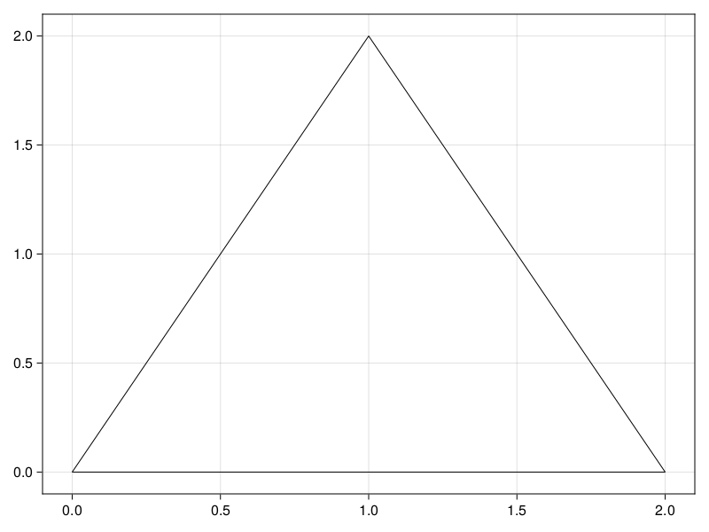

```julia
points = [(0.0, 0.0), (2.0, 0.0), (1.0, 2.0)]
tri = triangulate(points)
fig, ax, sc = triplot(tri)
fig
```

Note that we use a structure for `points` that is mutable so that points can be pushed into it.

We now want to insert a vertex into the triangulation. To do this, we use `add_point!` and provide the coordinates of the new point. There is a method which uses the index of the vertex rather than the coordinates, but we don't use that here as the points to be added are not already in `points`. Here, we add a point at `(1.0, 0.5)`.

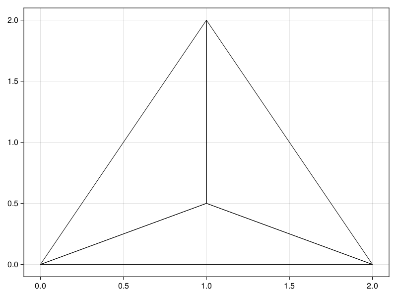

```julia
add_point!(tri, 1.0, 0.5)
fig, ax, sc = triplot(tri)
```

This is still a valid Delaunay triangulation, unsurprisingly due to the small number of points. One issue with this is when we try to add a point outside of the boundary. For example, if we try to add a point at `(0.0, 1.0)`, we get an error:

```julia
add_point!(tri, 0.0, 1.0)
```

```
BoundsError([(0.0, 0.0), (2.0, 0.0), (1.0, 2.0), (1.0, 0.5)], (0,))
```

This is a `BoundsError`, because the triangulation has had to walk into the boundary but failed to find any ghost triangles. By default, `triangulate` deletes the ghost triangles once it's done, but we should have used `delete_ghosts = false` to keep them, since ghost triangles are necessary for the algorithm to navigate around the boundary. Anytime you need to perform some operation including a point outside of the boundary, you need to be sure that you have ghost triangles. We can still add them back in using `add_ghost_triangles!`:

```julia
add_ghost_triangles!(tri);
```

Now we can add that point in.

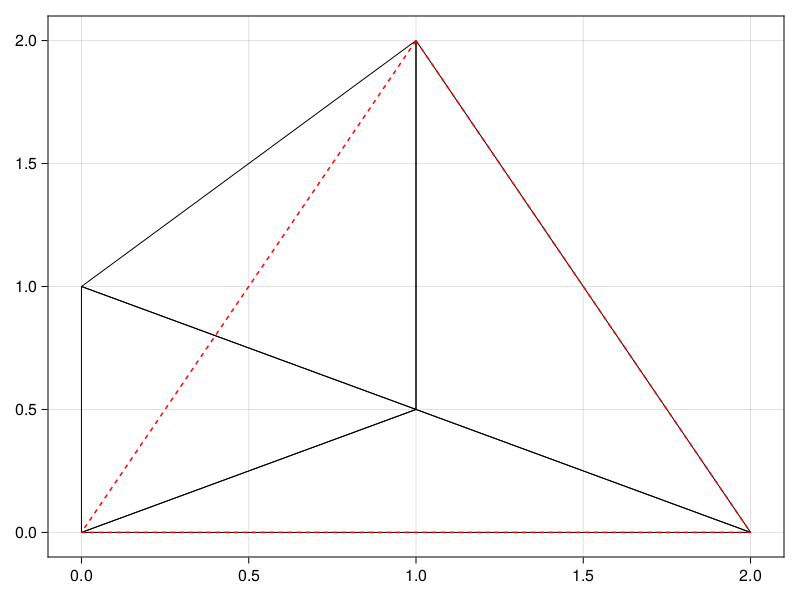

```julia
add_point!(tri, 0.0, 1.0)
fig, ax, sc = triplot(tri, show_convex_hull=true)
fig
```

Another issue is that the convex hull is not updated as we add (or delete) points for performance reasons. If we do want to fix the convex hull, we can use `convex_hull!(tri)`.

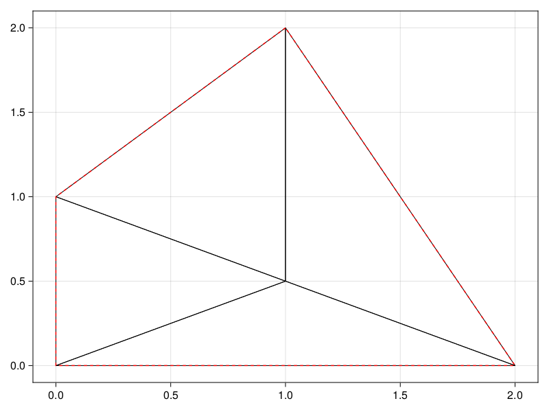

```julia
convex_hull!(tri)
fig, ax, sc = triplot(tri, show_convex_hull=true)
fig
```

We now have the same triangulation that we would have had if we had done `triangulate` on this set of points originally. To now push this further, let's add in a bunch of random points.

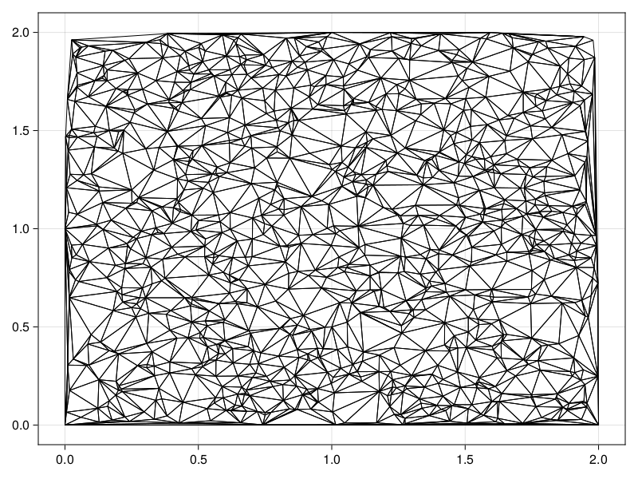

```julia
rng = StableRNG(123)
for _ in 1:1000
    new_point = 2rand(rng, 2)
    add_point!(tri, new_point)
end
fig, ax, sc = triplot(tri)
fig
```

Let us now demonstrate how to delete points. To do this, we use `delete_point!`. This function takes vertices rather than coordinates, identifying the corresponding point in `points` by its index. Let us demonstrate this operation by deleting all points within a distance of `1/2` around `(1.0, 1.0)`.

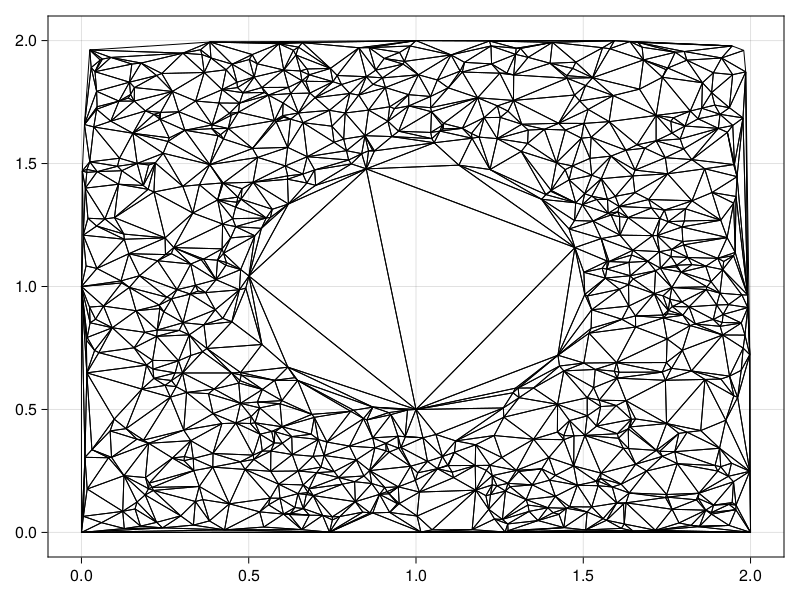

```julia
vertices_to_delete = Iterators.filter(each_solid_vertex(tri)) do i
    p = get_point(tri, i)
    r2 = (getx(p) - 1.0)^2 + (gety(p) - 1.0)^2
    return r2 < 1 / 2^2
end
for i in vertices_to_delete
    delete_point!(tri, i)
end
fig, ax, sc = triplot(tri)
fig
```

Note that in this situation, `points` still contains those points that we have now deleted. This is the reason to be careful about using, say, `each_point` rather than `each_solid_vertex`. This triangulation is also still Delaunay. We can also remove points that are on the boundary. Let us remove all points on the boundary so that a new boundary is formed.

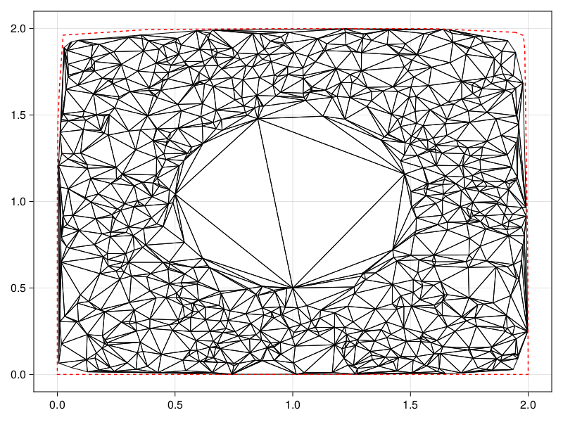

```julia
convex_hull!(tri) # reconstruct it
idx = get_convex_hull_indices(tri)
for i in @views idx[begin:(end-1)] # idx[1] == idx[end], so don't try and delete again
    delete_point!(tri, i)
end
fig, ax, sc = triplot(tri, show_convex_hull=true)
fig
```

Note that you will still need to reconstruct the convex hull again if you need to use it (you do not need to for operations like these–a broken convex hull is not a concern for the triangulation algorithms–, it's just if you actually want to use the convex hull directly).

```julia
get_convex_hull(tri)
```

```
Convex hull.
    Indices:
14-element Vector{Int64}:
 350
 202
   3
 769
 540
 689
 181
   5
   1
   2
 237
 912
 473
 350
```

```julia
convex_hull!(tri)
get_convex_hull(tri)
```

```
Convex hull.
    Indices:
29-element Vector{Int64}:
  45
 324
 618
 250
 869
 551
 727
 263
 403
 523
   ⋮
 743
 933
 777
 515
 461
 430
 934
 994
  45
```

## Just the code

An uncommented version of this example is given below. You can view the source code for this file [here](https://github.com/DanielVandH/DelaunayTriangulation.jl/tree/new-docs/docs/src/literate_tutorials/operations_vertex_insertion_deletion.jl).

```julia
using DelaunayTriangulation
using CairoMakie
using StableRNGs

points = [(0.0, 0.0), (2.0, 0.0), (1.0, 2.0)]
tri = triangulate(points)
fig, ax, sc = triplot(tri)
fig

add_point!(tri, 1.0, 0.5)
fig, ax, sc = triplot(tri)

add_point!(tri, 0.0, 1.0)

add_ghost_triangles!(tri);

add_point!(tri, 0.0, 1.0)
fig, ax, sc = triplot(tri, show_convex_hull=true)
fig

convex_hull!(tri)
fig, ax, sc = triplot(tri, show_convex_hull=true)
fig

rng = StableRNG(123)
for _ in 1:1000
    new_point = 2rand(rng, 2)
    add_point!(tri, new_point)
end
fig, ax, sc = triplot(tri)
fig

vertices_to_delete = Iterators.filter(each_solid_vertex(tri)) do i
    p = get_point(tri, i)
    r2 = (getx(p) - 1.0)^2 + (gety(p) - 1.0)^2
    return r2 < 1 / 2^2
end
for i in vertices_to_delete
    delete_point!(tri, i)
end
fig, ax, sc = triplot(tri)
fig

convex_hull!(tri) # reconstruct it
idx = get_convex_hull_indices(tri)
for i in @views idx[begin:(end-1)] # idx[1] == idx[end], so don't try and delete again
    delete_point!(tri, i)
end
fig, ax, sc = triplot(tri, show_convex_hull=true)
fig

get_convex_hull(tri)

convex_hull!(tri)
get_convex_hull(tri)
```

*This page was generated using Literate.jl.*